# R Notebook

The file project_management.csv contains data sampled from the recent work schedule of a small construction company. Column estimated_length contains the estimated length of a building job in days, while column actual_length contains the actual recorded length of the job in days.

We are interested in determining the accuracy of the job estimations made by the company using simple linear regression, so we will eventually want to run a simple linear regression using actual_length as the dependent variable, and estimated_length as the independent variable.

```r
library(tidyverse)
library(modelr)
library(infer)
library(broom)
```

Load the data into a dataframe project

```r
project <- read_csv("data/project_management.csv")
```

Plot the data, taking estimated_length as the independent variable and actual_length as the dependent variable.

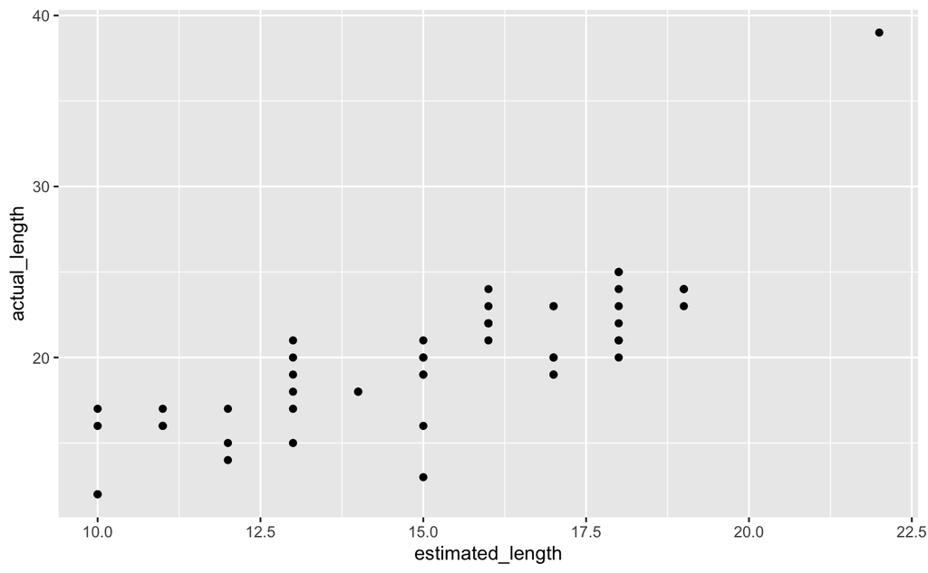

Calculate the correlation coefficient of estimated_length and actual_length and interpret the value you obtain.

| r |
| --- |
| 0.8046597 |

`it's 0.804, this suggests a strong possitive correlation between the two variable.`

Perform a simple linear regression using actual_length as the dependent variable, and estimated_length as the independent variable. Save the model object to a variable.

```r
model <- lm(formula = actual_length ~ estimated_length, data = project)
```

Interpret the regression coefficient of estimated_length (i.e. slope, gradient) you obtain from the model. How do you interpret the r2 value reported by the model?

```r
summary(model)
```

```
Call:
lm(formula = actual_length ~ estimated_length, data = project)

Residuals:
    Min      1Q  Median      3Q     Max
-6.7687 -1.6513  0.1195  1.1252 10.6669

Coefficients:
                 Estimate Std. Error t value Pr(>|t|)
(Intercept)        1.4164     2.0069   0.706    0.484
estimated_length   1.2235     0.1303   9.389 1.91e-12 ***
---
Signif. codes:  0 ‘***’ 0.001 ‘**’ 0.01 ‘*’ 0.05 ‘.’ 0.1 ‘ ’ 1

Residual standard error: 2.606 on 48 degrees of freedom
Multiple R-squared:  0.6475,    Adjusted R-squared:  0.6401
F-statistic: 88.16 on 1 and 48 DF,  p-value: 1.911e-12
```

```
from the summary we can find out the slope: 1.2235, r_sq is 0.6475. It's not
very high but not low either, it's okay valur for 0.6475, which means our model
is not good but not bad either.
```

Is the relationship statistically significant? Remember, to assess this you need to check the p-value of the regression coefficient (or slope/gradient). But you should first check the regression diagnostic plots to see if the p-value will be reliable (don’t worry about any outlier points you see in the diagnostic plots, we’ll return to them in the extension).

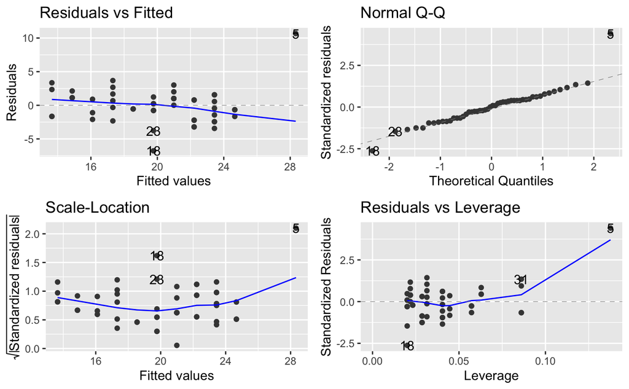

```r
library(ggfortify)
autoplot(model)
```

```
this looks fine, p_value from above, is very samll: 1.911e-12
so the relationship is significant,
```